# README

20331568

12/5/2021

```r
# ============== Preamble to load packages ========================== #
if(!require("devtools")){install_github("devtools")}
```

```r
library(devtools)

# Install the required packages in elagant approach
pacman::p_load(
    "tidyverse",
    "devtools",
    "rugarch",
    "forecast",
    "tbl2xts",
    "lubridate",
    "PerformanceAnalytics",
    "ggthemes",
    "robustbase",
    "tbl2xts",
    "PerformanceAnalytics",
    "ggplot2",
    "tidyverse",
    "fmxdat",
    "extrafont",
    "TTR",
    "naniar",
    "readr",
    "dplyr",
    "tidyr",
    "rmsfuns",
    "naniar",
    "fEcofin"
)
```

#Question 1

## Data question 1

```r
SA_bonds <-
    read_rds("data/SA_Bonds.rds") # SA bond 2 year, 3 month and 10 year

BE_Infl <- read_rds("data/BE_Infl.rds")
bonds_2y <- read_rds("data/bonds_2y.rds") # International comparison
bonds_10y <- read_rds("data/bonds_10y.rds") # Internarion
usdzar <- read_rds("data/usdzar.rds") # US ZA currency
ZA_Infl <- read_rds("data/ZA_Infl.rds") # Inflation in South Africa (High inflation rate, leads to bond holders requring higher  returns off bonds and thus )
IV <- read_rds("data/IV.rds") # Volitility index
```

For Question 1, we are given seven distinct datasets. The primary data set is ‘SA bonds,’ which has three distinct features that indicate South African bond yields. These can be thought of as sentiment towards South African debt, in short term (3-month bond), medium term (2-year bond) and long term (10-year bond).

```r
# ================ SA_bonds ==================== #

dim(SA_bonds)
```

```
## [1] 5715    4
```

```r
colnames(SA_bonds)
```

```
## [1] "date"    "SA_3M"   "ZA_10Yr" "ZA_2Yr"
```

```r
# transformation: reshape to plot

xts.SA_bonds <-
    SA_bonds %>%
    select("date", "SA_3M", "ZA_10Yr", "ZA_2Yr") %>%
    tbl_xts()

# Look at the data: data is daily
head(SA_bonds, 3)
```

```
## # A tibble: 3 x 4
##   date       SA_3M ZA_10Yr ZA_2Yr
##   <date>     <dbl>   <dbl>  <dbl>
## 1 1999-12-06  11.3    14.0   12.7
## 2 1999-12-07  11.3    14.0   12.7
## 3 1999-12-08  11.3    14.1   12.8
```

```r
tail(SA_bonds, 3)
```

```
## # A tibble: 3 x 4
##   date       SA_3M ZA_10Yr ZA_2Yr
##   <date>     <dbl>   <dbl>  <dbl>
## 1 2021-10-27  3.68    10.1   5.48
## 2 2021-10-28  3.68    10.2   5.55
## 3 2021-10-29  3.68    10.2   5.61
```

# EDA of SA bonds

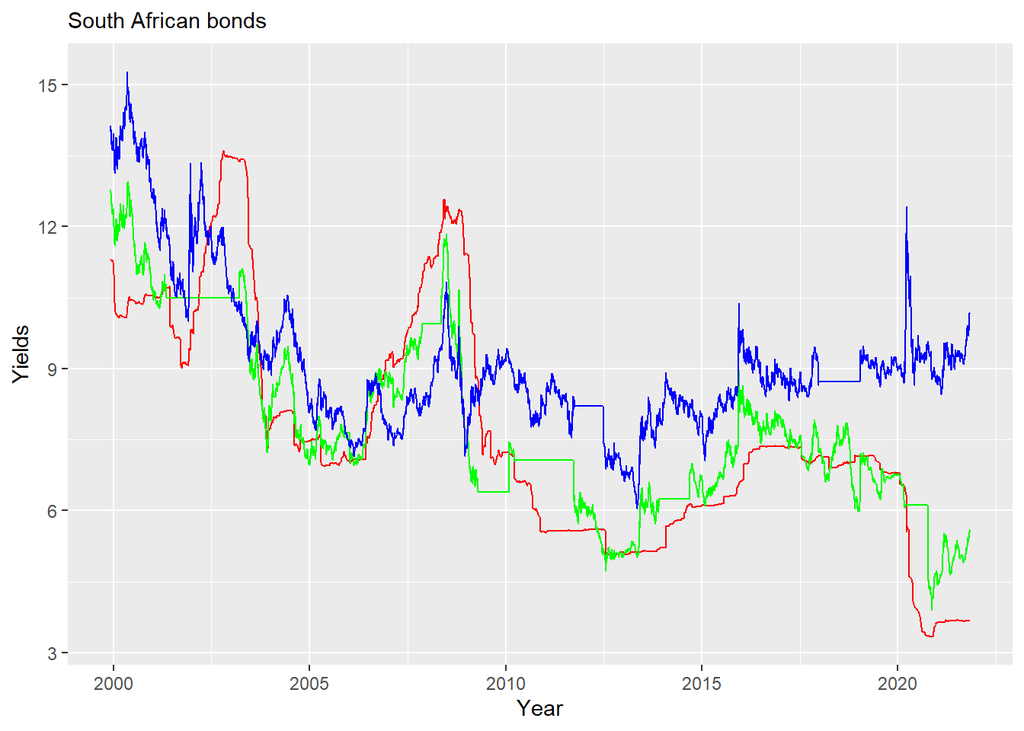

```r
p1 <-      ggplot(SA_bonds, aes(x=date)) +
    geom_line( aes(y = SA_3M), size = 0.5, colour = "red") +
    geom_line(aes(y = ZA_2Yr) ,size = 0.5, colour = "green") +
    geom_line(aes( y = ZA_10Yr) ,size = 0.5, colour = "blue") +
    labs(
        x = "Year",
        y = "Yields",
        subtitle = "South African bonds"
    )


print(p1)
```

```r
my.cols <- heat.colors(3, alpha=1)
my.names <- c("SA_3M", "ZA_10Yr", "ZA_2Yr" )
names(my.cols) <- my.names

##Then rearrange your data frame
library(reshape2)
dd = melt(SA_bonds, id=c("date"))

#p2 <-  ggplot(dd) + geom_line(aes(x=date, y=value, colour=variable))

p2 <-      ggplot(dd) +
    geom_line( aes(y = SA_3M), size = 0.5, colour = "red") +
    geom_line(aes(y = ZA_2Yr) ,size = 0.5, colour = "green") +
    geom_line(aes( y = ZA_10Yr) ,size = 0.5, colour = "blue") +
    labs(
        x = "Year",
        y = "Yields",
        subtitle = "South African bonds"
    ) + scale_colour_manual(values=c("red","green","blue"))
```

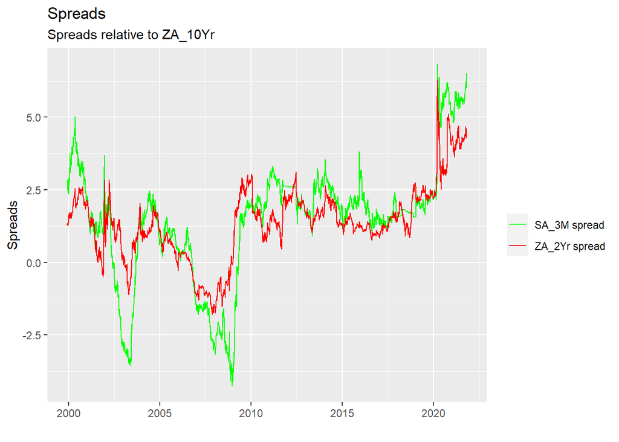

```r
p3 <-
ggplot(data = SA_bonds, aes(x = date)) +
  geom_line(aes(y =ZA_10Yr-SA_3M, colour = "SA_3M spread")) +
  geom_line(aes(y =ZA_10Yr-ZA_2Yr, colour = "ZA_2Yr spread")) +
  scale_colour_manual("",
                      breaks = c("SA_3M spread", "ZA_2Yr spread"),
                      values = c("SA_3M spread"="green", "ZA_2Yr spread"="red")) +
  xlab(" ") +
  scale_y_continuous("Spreads") +
  labs(title="Spreads",
       subtitle = "Spreads relative to ZA_10Yr")

p3
```

```r
# Both are daily but different dimensions and dates
print(dim(bonds_2y) == dim(SA_bonds))
```

```
## [1] FALSE FALSE
```

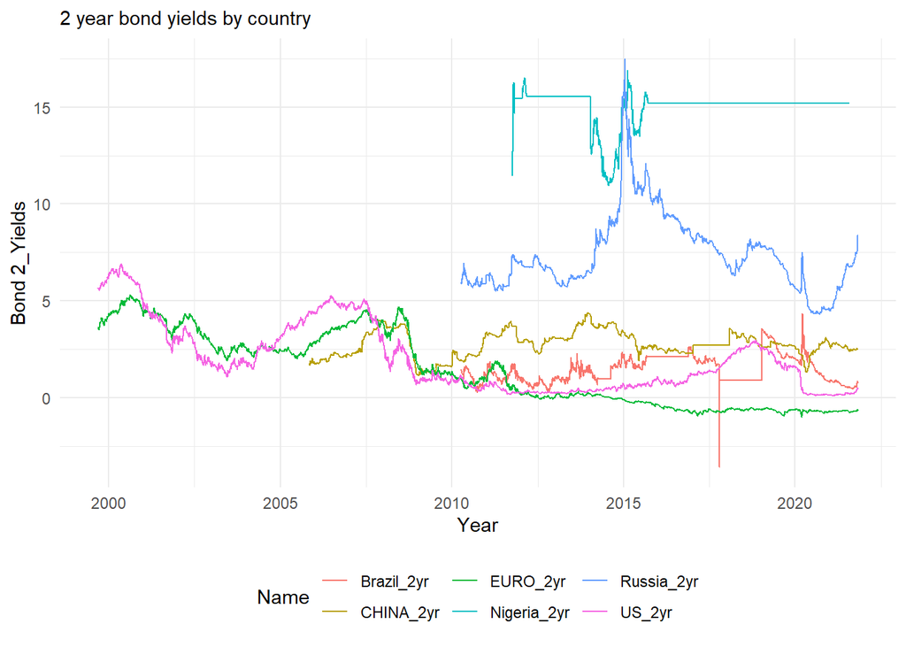

```r
#
p5 <-
bonds_2y %>%
 filter(date >= "1999-09-09" & date <= "2021-10-29") %>%
 filter(Name %in% c("Brazil_2yr",
"CHINA_2yr", "EURO_2yr", "Nigeria_2yr", "US_2yr", "Russia_2yr")) %>%
 ggplot() +
  aes(x = date, y = Bond_2Yr, colour = Name) +
  geom_line(size = 0.5) +
  scale_color_hue(direction = 1) +
  labs(
        x = "Year",
        y = "Bond 2_Yields",
        subtitle = "2 year bond yields by country") +
  theme_minimal()+
 theme(legend.position = "bottom")

print(p5)
```

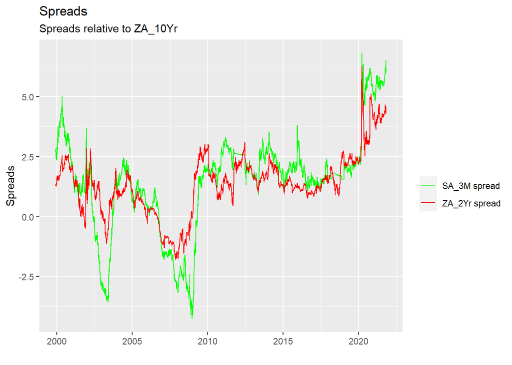

```r
ggplot(data = SA_bonds, aes(x = date)) +
  geom_line(aes(y =ZA_10Yr-SA_3M, colour = "SA_3M spread")) +
  geom_line(aes(y =ZA_10Yr-ZA_2Yr, colour = "ZA_2Yr spread")) +
  scale_colour_manual("",
                      breaks = c("SA_3M spread", "ZA_2Yr spread"),
                      values = c("SA_3M spread"="green", "ZA_2Yr spread"="red")) +
  xlab(" ") +
  scale_y_continuous("Spreads") +
  labs(title="Spreads",
       subtitle = "Spreads relative to ZA_10Yr")
```

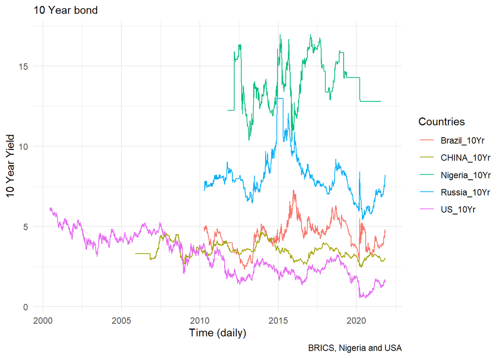

```r
p4 <-
bonds_10y %>%
 filter(date >= "2000-06-07" & date <= "2021-10-29") %>%
 filter(Name %in% c("Brazil_10Yr",
"CHINA_10Yr", "Nigeria_10Yr", "Russia_10Yr", "US_10Yr")) %>%
 ggplot() +
 aes(x = date, y = Bond_10Yr, colour = Name) +
 geom_line(size = 0.5) +
 scale_color_hue(direction = 1) +
 labs(x = "Time (daily)", y = "10 Year Yield", subtitle = "10 Year bond", caption = "BRICS, Nigeria and USA",
 color = "Countries") +
 theme_minimal()
p4
```

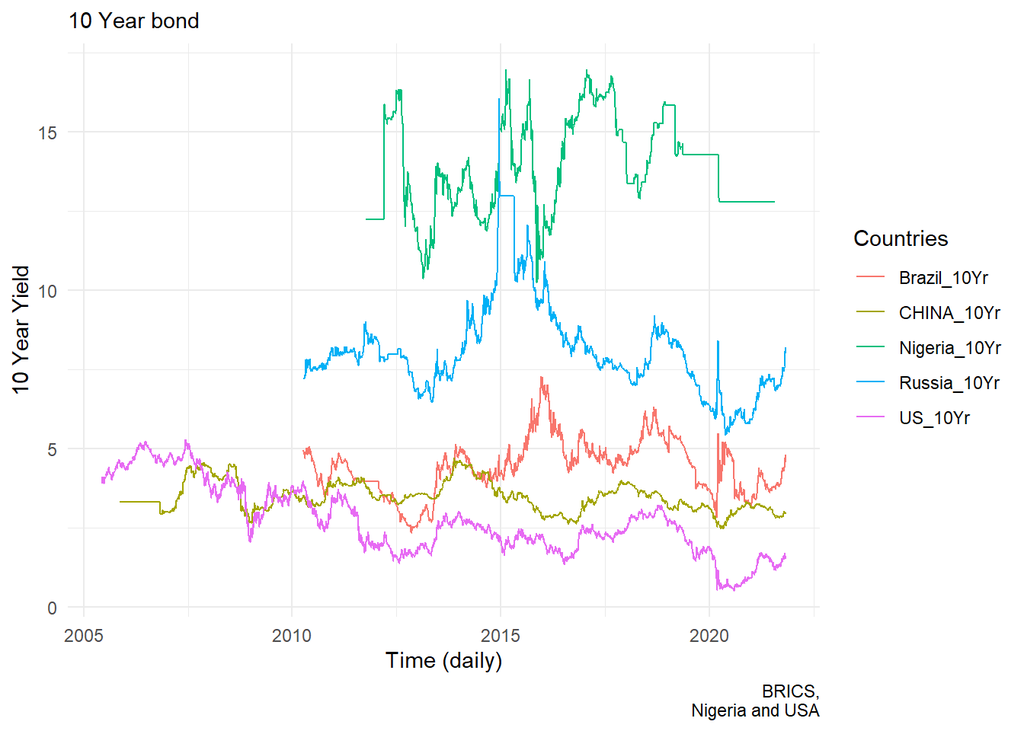

```r
bonds_10y %>%
 filter(date >= "2005-06-08" & date <= "2021-10-29") %>%
 filter(Name %in% c("Brazil_10Yr",
"CHINA_10Yr", "Nigeria_10Yr", "Russia_10Yr", "US_10Yr")) %>%
 ggplot() +
  aes(x = date, y = Bond_10Yr, colour = Name) +
  geom_line(size = 0.5) +
  scale_color_hue(direction = 1) +
  labs(
    x = "Time (daily)",
    y = "10 Year Yield",
    subtitle = "10 Year bond",
    caption = "BRICS,
    Nigeria and USA",
    color = "Countries"
  ) +
  theme_minimal()
```

```r
# Compare the spreads for the US with the spread of South Africa

# index 2 year bond
temp1 =  bonds_2y[bonds_2y$Name == "US_2yr",]

temp2 = bonds_10y[bonds_10y$Name == "US_10Yr",]

# same dimensions
dim(temp1) == dim(temp2)
```

```
## [1] TRUE TRUE
```

```r
# Calculate US spread
temp1$US_Spread = temp2$Bond_10Yr -  temp1$Bond_2Yr

# Calculate ZA spread
SA_bonds$ZA_spread = SA_bonds$ZA_10Yr - SA_bonds$ZA_2Yr

# False
#min(temp$date) == min(SA_bonds$date)

# True
#min(temp$date) < min(SA_bonds$date)

# true
#max(temp$date) == max(SA_bonds$date)

# index temp to SA_bonds minimum date
tempsub = temp1[temp1$date >= min(SA_bonds$date),]


compareUSZA = merge(SA_bonds, tempsub)
```

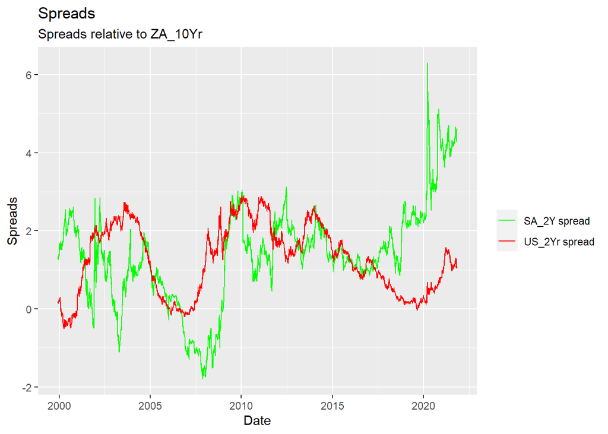

```r
p6 <- ggplot(data=compareUSZA, aes(x = date)) +
  geom_line(aes(y =ZA_spread, colour = "SA_2Y spread")) +
  geom_line(aes(y =US_Spread, colour = "US_2Yr spread")) +
  scale_colour_manual("",
                      breaks = c("SA_2Y spread", "US_2Yr spread"),
                      values = c("SA_2Y spread"="green", "US_2Yr spread"="red")) +
  xlab(" ") +
  scale_y_continuous("Spreads") +
  labs(title="Spreads",
       x = "Date",
       subtitle = "Spreads relative to ZA_10Yr")

p6
```

[figure not shown]

```r
# Let's look at the rolling correlation between values
temp <- compareUSZA %>%
    select(date, ZA_spread, US_Spread)


# rolling correlation
window_size = 120 # 120 day rolling correlation
cor1 <- data.frame(rollapply( temp,width=window_size, function(x) {cor(as.numeric(x[,2]), as.numeric(x[,3]))}, by.column=FALSE) )

plot(cor1)
```

Other considerations,

- VIX

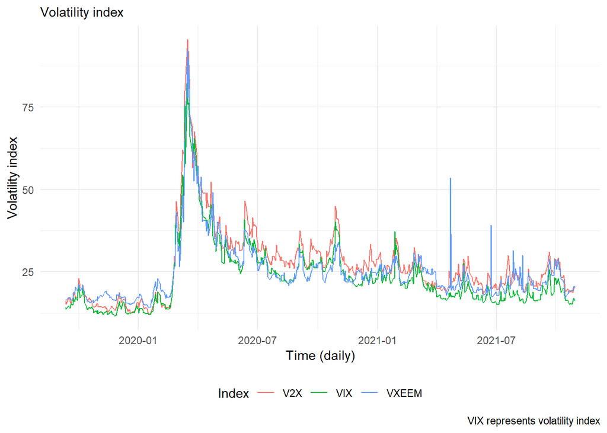

```r
p8 <- IV %>%
 filter(date >= "2019-09-12" & date <= "2021-10-29") %>%
 ggplot() +
 aes(x = date, y = Price, colour = Name) +
 geom_line(size = 0.5) +
 scale_color_hue(direction = 1) +
 labs(x = "Time (daily)", y = "Volatility index", subtitle = "Volatility index", caption = "VIX represents volatility index",
 color = "Index") +
 theme_minimal() +
 theme(legend.position = "bottom")

print(p8)
```

#Question 2

Load the data

```r
T40 <- read_rds("data/T40.rds")
RebDays <- read_rds("data/Rebalance_days.rds")
```

Glimpse of the data

```r
#Glimpse of the data
print(dim(T40))
```

```
## [1] 146383      8
```

```r
print(dim(RebDays))
```

```
## [1] 221   2
```

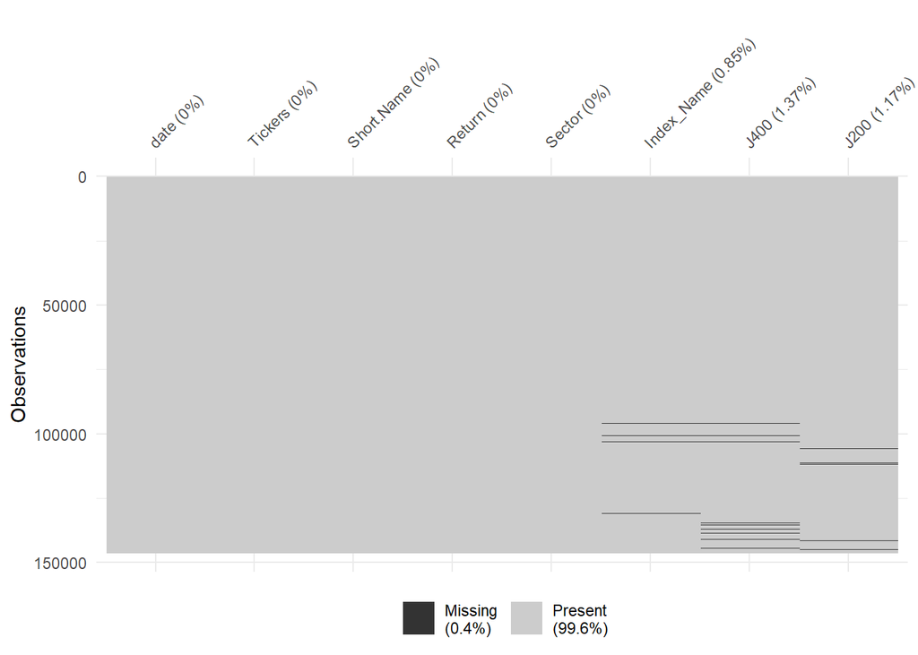

```r
# Missing data is present in the dataset
g1 <- vis_miss(T40,warn_large_data=FALSE)
g1
```

```r
glimpse(T40)
```

```
## Rows: 146,383
## Columns: 8
## $ date       <date> 2008-01-02, 2008-01-02, 2008-01-02, 2008-01-02, 2008-01-02~
## $ Tickers    <chr> "AGL SJ Equity", "BHP SJ Equity", "CFR SJ Equity", "MTN SJ ~
## $ Short.Name <chr> "ANGLO AMER PLC", "BHP GROUP PLC", "RICHEMONT-DR", "MTN GRO~
## $ Return     <dbl> 0.0105538000, 0.0139693163, 0.0054093890, 0.0268623939, 0.0~
## $ Sector     <chr> "Resources", "Resources", "Industrials", "Industrials", "In~
## $ Index_Name <chr> "Large_Caps", "Large_Caps", "Large_Caps", "Large_Caps", "La~
## $ J400       <dbl> 0.074652404, 0.068631932, 0.043070409, 0.105785980, 0.03808~
## $ J200       <dbl> 0.156064088, 0.143478030, 0.067530418, 0.066345054, 0.05971~
```

```r
glimpse(RebDays)
```

```
## Rows: 221
## Columns: 2
## $ date      <date> 2002-09-20, 2002-09-23, 2002-12-20, 2002-12-23, 2003-03-20,~
## $ Date_Type <chr> "Reb Trade Day", "Effective Date", "Reb Trade Day", "Effecti~
```

```r
# Look at unique stocks per day
temp <- T40 %>% group_by(date) %>% tally()
unique(temp$n)
```

```
## [1] 41 40 42 43 39 44 45
```

```r
# test for J200
temp <- T40 %>% group_by(date) %>% summarise(sumval = sum(J200))
unique(temp$sumval)
```

```
## [1]  1  1 NA
```

```r
# test for J400
temp <- T40 %>% group_by(date) %>% summarise(sumval = sum(J400))
unique(temp$sumval)
```

```
## [1]  1  1 NA
```

We know that the return of the portfolio can be calculated as
$$r_{\text{portfilio}}(t) = \sum_{i} w_{i}(t) \times r_{i}(t),$$
where $w_{i}(t)$ is the weight of stock $i$ and $r_{i}(t)$ is the return of stock $i$ for all $i$ stocks.

```r
T40<- T40 %>% group_by(date) %>%
              mutate(J200return = J200 * Return,
              J400return = J400 * Return
                                  )

# possibly log returns since all are greater than 0
sum(T40$J400return < 0)
```

```
## [1] NA
```

```r
sum(T40$J200return < 0)
```

```
## [1] NA
```

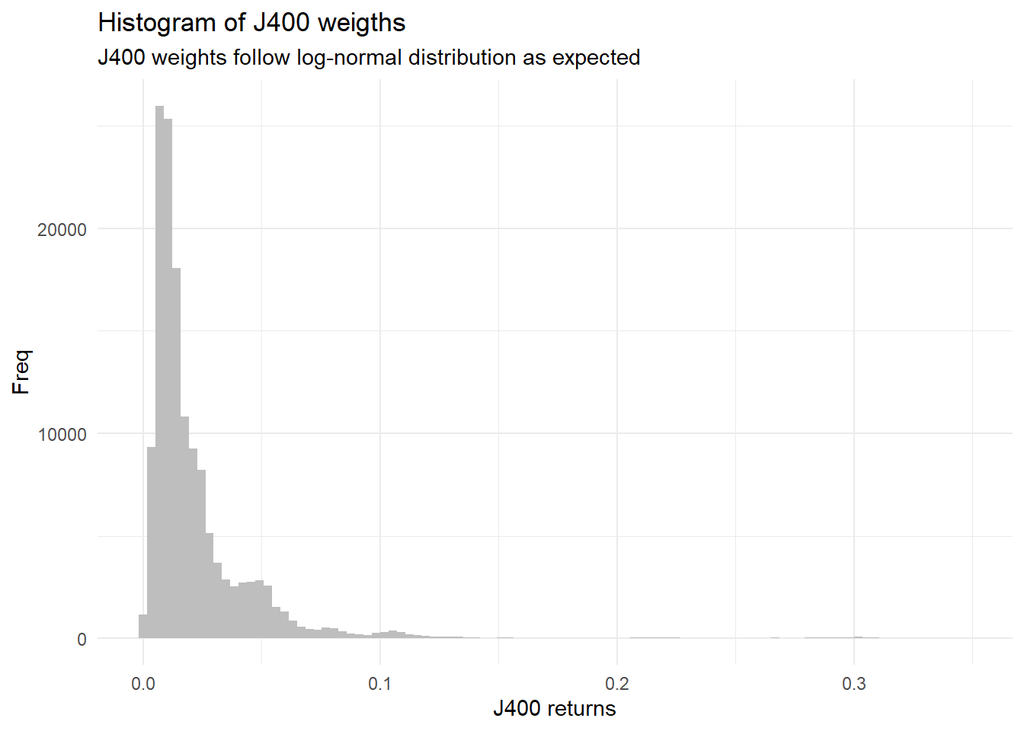

```r
# Can't have a negative weight in a portfolio
g2 <- T40 %>%
 ggplot() +
 aes(x = J400) +
 geom_histogram(bins = 100L, fill = "grey") +
 labs(x = "J400 returns",
 y = "Freq", title = "Histogram of J400 weigths", subtitle = "J400 weights follow log-normal distribution as expected")  +
 theme_minimal()

print(g2)
```

[figure not shown]

```r
g3 <- T40 %>%
 ggplot() +
 aes(x = J400return) +
 geom_histogram(bins = 200L, fill = "grey") +
 labs(x = "J400 returns",
 y = "Freq", title = "Histogram of J400 returns", subtitle = "J400 returns follow log-normal distribution") +
 theme_minimal()
print(g3)
```

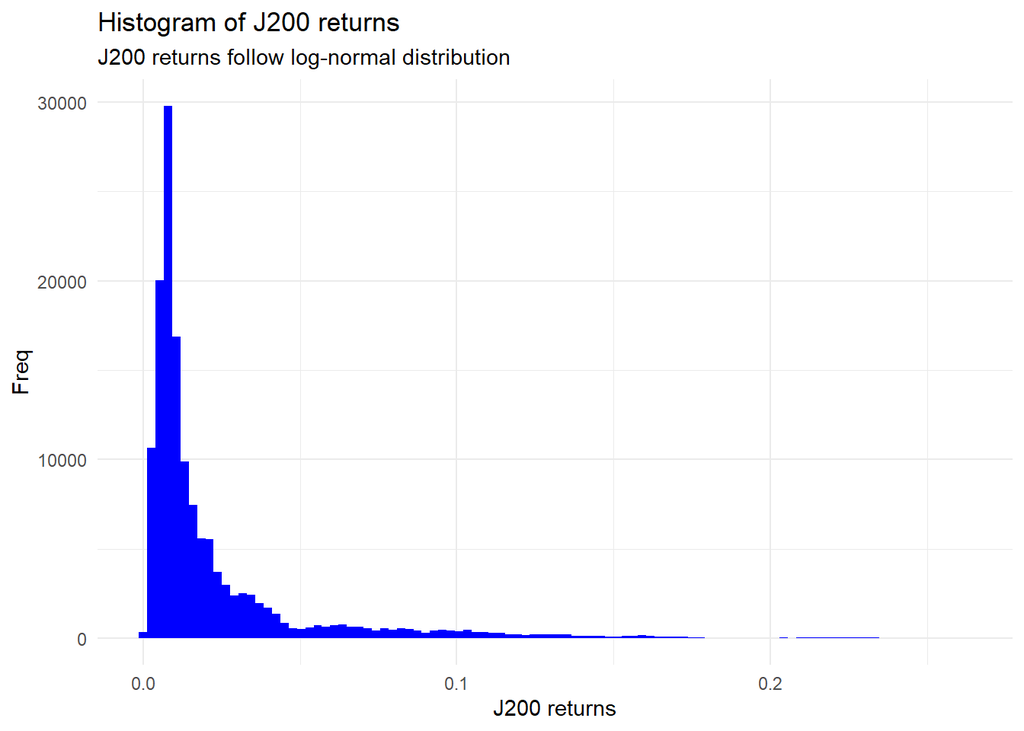

```r
T40 %>%
 filter(Return >= -0.74 & Return <= 0.14) %>%
 ggplot() +
 aes(x = J200) +
 geom_histogram(bins = 100L, fill = "blue") +
 labs(x = "J200 returns",
 y = "Freq", title = "Histogram of J200 returns", subtitle = "J200 returns follow log-normal distribution") +
 theme_minimal()
```

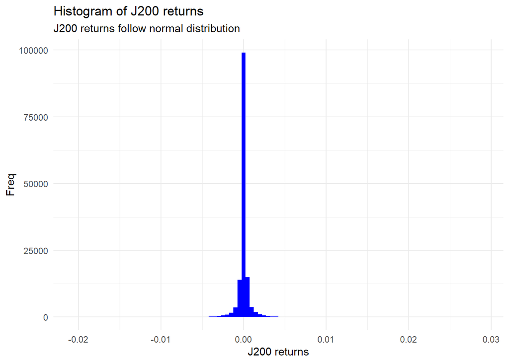

```r
g4 <- T40 %>%
 ggplot() +
 aes(x = J200return) +
 geom_histogram(bins = 100L, fill = "blue") +
 labs(x = "J200 returns",
 y = "Freq", title = "Histogram of J200 returns", subtitle = "J200 returns follow normal distribution") +
 theme_minimal()
g4
```

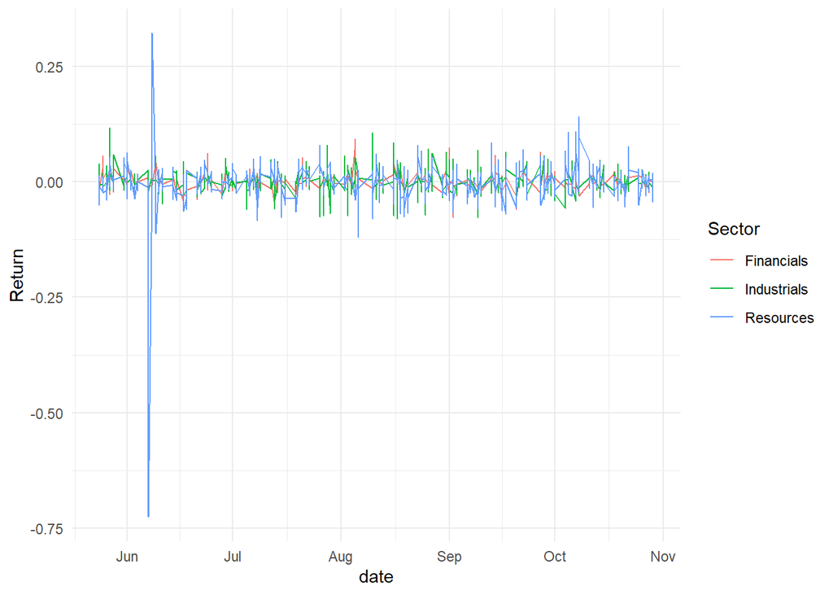

```r
g5 <- T40 %>%
 filter(date >= "2021-05-23" & date <= "2021-10-29") %>%
 ggplot() +
  aes(x = date, y = Return, colour = Sector) +
  geom_line(size = 0.5) +
  scale_color_hue(direction = 1) +
  theme_minimal()

print(g5)
```

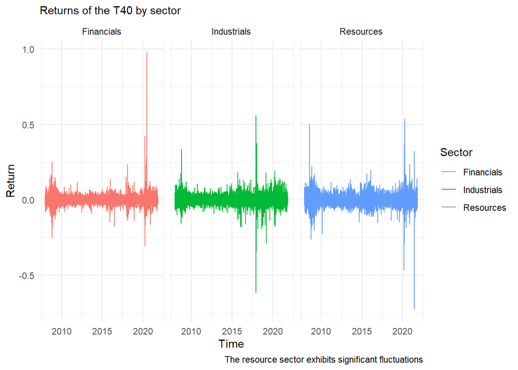

```r
library(ggplot2)

g6 <- ggplot(T40) +
 aes(x = date, y = Return, colour = Sector) +
 geom_line(size = 0.5) +
 scale_color_hue(direction = 1) +
 labs(x = "Time", y = "Return", subtitle = "Returns of the T40 by sector", caption = "The resource sector exhibits significant fluctuations") +
 theme_minimal() +
 facet_wrap(vars(Sector))
print(g6)
```

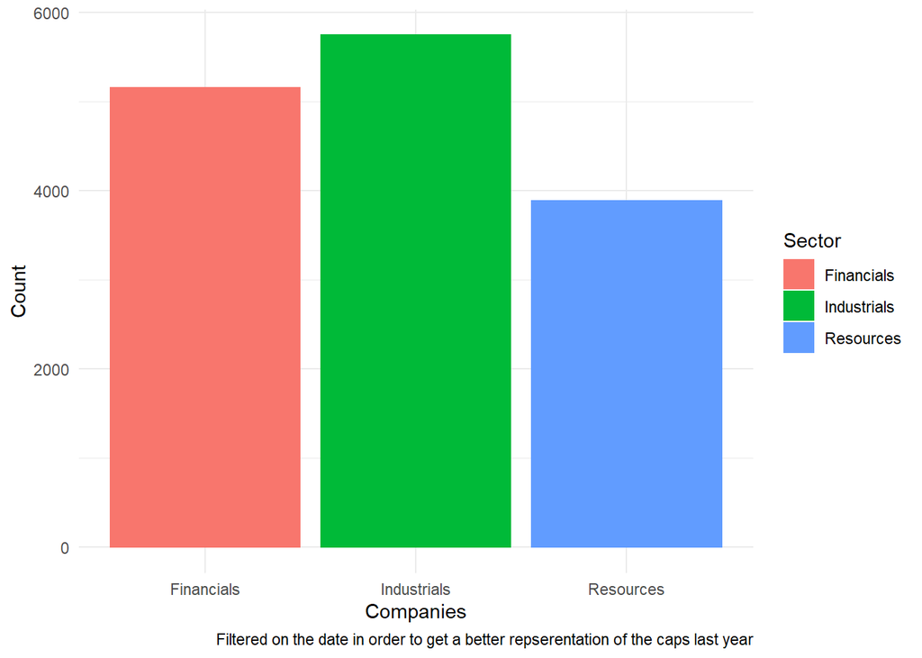

```r
g7 <-
    T40 %>%
    filter(date >= "2020-06-11" & date <= "2021-10-29") %>%
    ggplot() +
    aes(x = Sector, fill = Sector, colour = Sector) +
    geom_bar() +
    scale_fill_hue(direction = 1) +
    scale_color_hue(direction = 1) +
    labs(x = "Companies", y = "Count", caption = "Filtered on the date in order to get a better repserentation of the caps last year") +
    theme_minimal()
print(g7)
```

# Look at cumulative returns

```r
#T40.xts <-  T40 %>tbl2xts::xts_tbl()


# transformation: reshape to plot

xts.T40 <-
    T40 %>%
    tbl_xts()
colnames(xts.T40)
```

```
## [1] "Return"     "J400"       "J200"       "J200return" "J400return"
```

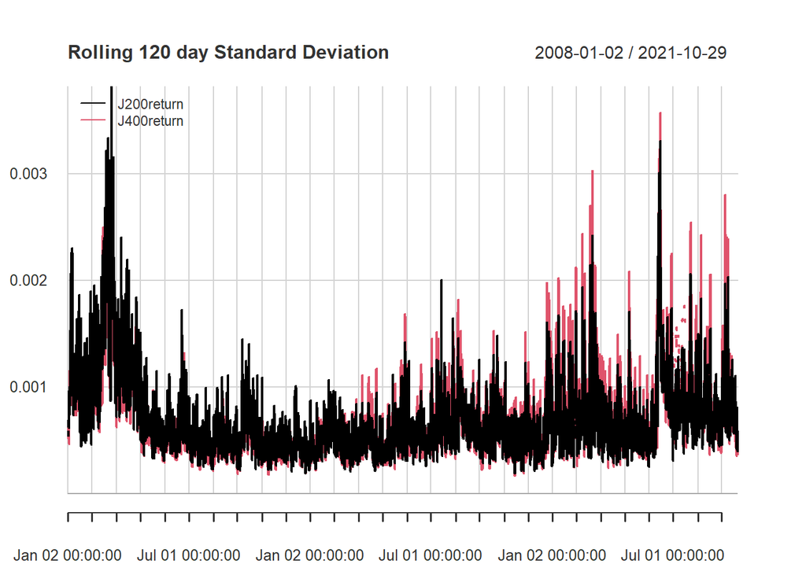

```r
window_size = 120

g8 <-
chart.RollingPerformance(
    R = xts.T40[, c("J200return", "J400return")],
    FUN = "sd",
    width = window_size,
    main = "Rolling 120 day Standard Deviation",
    legend.loc = "topleft"
)

print(g8)
```

```r
# Calculate rolling returns
T40 <- T40  %>%
    # Set NA Rets to zero to make cumprod work:
    mutate(J200return = coalesce(J200return, 0)) %>%
    mutate(Cum_Ret200= cumprod(1 + J200return)) %>%
    mutate(J400return = coalesce(J400return, 0)) %>%
    mutate(Cum_Ret400 = cumprod(1 + J400return))
```

[figure not shown]

```r
g9 <- ggplot(T40) +
 aes(x = date, y = Cum_Ret200, colour = Sector) +
 geom_line(size = 0.5) +
 scale_color_hue(direction = 1) +
 labs(x = "Time(daily)", y = "Cumulative returns", caption = "Industrials had good cumulative returns in J200.",
 color = "Sector") +
 theme_minimal()

print(g9)
```

[figure not shown]

```r
g10 <- ggplot(T40) +
 aes(x = date, y = Cum_Ret400, colour = Sector) +
 geom_line(size = 0.5) +
 scale_color_hue(direction = 1) +
 labs(x = "Time(daily)", y = "Cumulative returns", caption = "Industrials had good cumulative returns in J400.",
 color = "Sector") +
 theme_minimal()
print(g10)
```

```r
#Cumret for J200 and J400 by Sector
# First: calculate ordinary returns
library(lubridate)

#------------------
# Step one: gather to make tidy:

#------------------
# Second: Calculate Cumulative Returns
T40_ <-  T40 %>%
# for cumulative returns - we have to change NA to zero, else
# an NA would break the chain....
mutate(J200return = coalesce(J200return, 0)) %>%
# Any NA in Returns is changed to zero
group_by(Sector) %>%
mutate(Cum_Ret200 = cumprod(1 + J200return)) %>% mutate(Cum_Ret400 = cumprod(1 + J400return))

# Bonus: Figure for Naspers:
g11 <- ggplot(T40) +
geom_line(aes(x = date, y = Cum_Ret200), color = "red") +
geom_line(aes(x = date, y = Cum_Ret400), color = "green")
theme_bw() + labs(title = "J200 and J400 cumulative Return", y = "Growth of R1 invested in 2003.")
```

[output not shown]

[output cut: 366 more lines]

[output not shown]

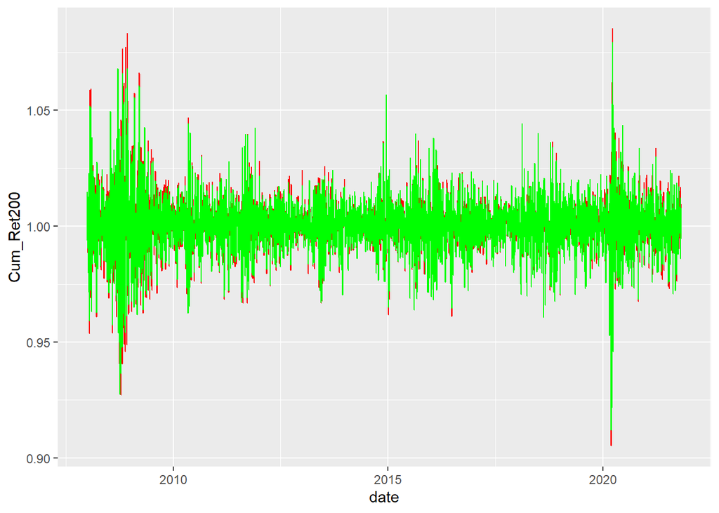

```r
print(g11)
```

#Question 3

Volatility comparison in understanding the concentration and commodity of returns with the Top 40 Indexes. Monthly volatility is stratified by computing the J200 index returns and comparing the return source concentrations for just times of high volatility.

```r
# Importing the data
T40 <- read_rds("data/T40.rds")
RebDays <- read_rds("data/Rebalance_days.rds")
```

Stratify returns during time of high volatility.

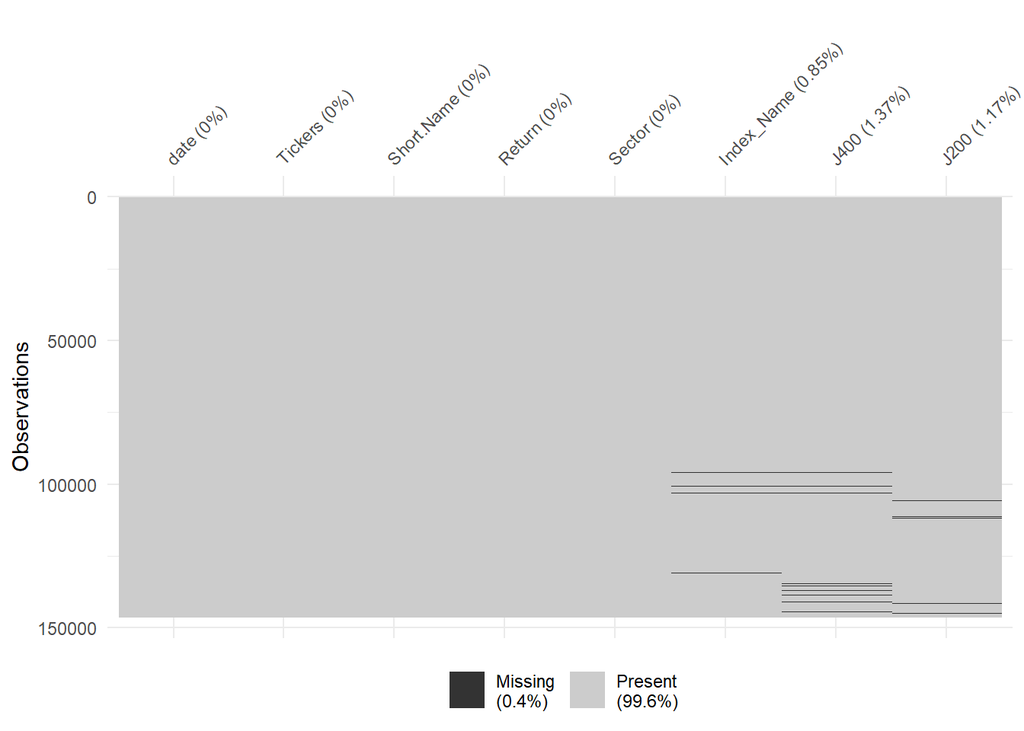

```r
# Look at the structure of the missing data
i1 <- naniar::vis_miss(T40,warn_large_data=FALSE)
i1
```

Block structure of the missing data suggests that the data is missing not at random (MNAR) meaning that there is some reason that the data is missing. We observe this directly as the data is missing in particular columns. We have to be weary of when the weights `J200` and `J400` have missing data but also when the `Return` is missing.

```r
T40 <- T40 %>% group_by(date) %>%
    # replace NA with zero for both Return and J200
    mutate(Return = coalesce(Return, 0)) %>%
    mutate(J200 = coalesce(J200, 0)) %>%
    # Calculate J200return from weight * value
    mutate(J200return = J200 * Return) %>%
    # remove the J400, could have also just selected the necessary parts only
    select(-J400)
```

```r
T40 <-

    T40 %>% group_by(Tickers) %>%
    mutate(Top = quantile(J200return, 0.99),
           Bot = quantile(J200return, 0.01)) %>%

    mutate(Return = ifelse(J200return > Top, Top,
                           ifelse(J200return < Bot, Bot, J200return))) %>%
    ungroup() %>%  mutate(YearMonth = format(date, "%Y%B"))
```

```r
# High volatile in the topquantile
T40SD <- T40  %>%
    mutate(YearMonth = format(date, "%Y%B")) %>%
    group_by(YearMonth) %>% summarise(SD = sd(J200return) * sqrt(52)) %>%
    mutate(TQ = quantile(SD, 0.8),
           BQ = quantile(SD, 0.2))
```

```r
hivolume <- T40SD %>%
    filter(SD > TQ) %>%
    pull(YearMonth)

lowvolume <- T40SD %>%
    filter(SD < BQ) %>%
    pull(YearMonth)
```

```r
# Create generic function to compare performance:

Perf_comparisons <- function(Idxs, YMs, Alias) {
    YMs <- hivolume

    Unconditional_SD <-
        Idxs %>%
        group_by(Tickers) %>%
        mutate(Full_SD = sd(Return) * sqrt(252)) %>%
        filter(YearMonth %in% YMs) %>%
        summarise(SD = sd(Return) * sqrt(252),
                  across(.cols = starts_with("Full"), .fns = max)) %>%
        arrange(desc(SD)) %>% mutate(Period = Alias) %>%
        group_by(Tickers) %>%
        mutate(Ratio = SD / Full_SD)

    Unconditional_SD

}
```

```r
#monthly high volatility tickers

hi <- Perf_comparisons(T40, YMs = Hi_Vol, Alias = "hivolume")

low <- Perf_comparisons(T40, YMs = Low_Vol, Alias = "lowvolume")
```

PCA Analysis:

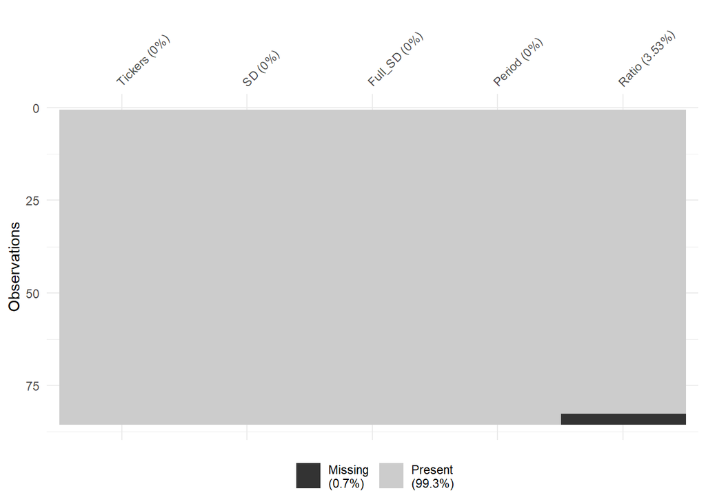

```r
naniar::vis_miss(hi,warn_large_data=FALSE)
```

The missingness profile shows the block structure of the missingness is from the ratio. After printing it out we see that these are stocks that are not in our group.

```r
#Removing missingness  resulting from the ration

hi <-na.omit(hi)
```

Now to center the J200returns mean

```r
T40_Centered <-
    T40 %>% group_by(Tickers) %>%
    mutate(J200return_centered = J200return - mean(J200return)) %>%
    ungroup()
```

Here we are only interested in Hi volatility periods as stratified above.

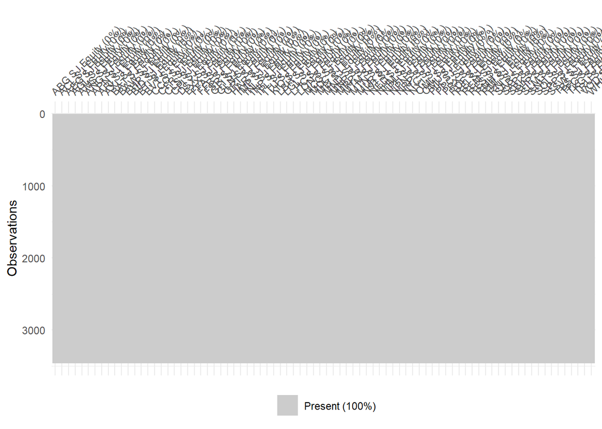

```r
pacman::p_load(fEcofin)
# create wide format
data_wide <- T40_Centered %>%
    filter(T40_Centered$Tickers %in% hi$Tickers) %>%
    mutate(Return = coalesce(Return, 0))  %>%
    select(date, Tickers, J200return_centered) %>%
    spread(Tickers,
           J200return_centered) %>%
    select(-date)


# Checked that all stocks are in the index at some time
temp <- data_wide[, colSums(is.na(data_wide)) != nrow(data_wide)]

# rebalancing cause stocks to move in and out of a portfolio
# these are the missing values that we saw in the vismiss and
# that we have to delete.
data_wide <- temp %>%
    mutate(across(everything(), replace_na, 0))


# now the data is full which is necessary for us to perform
# principle component analysis

print(vis_miss(data_wide))
```

```r
# perform PCA analysis
PCA <- prcomp(data_wide)
```

PCA use the covariance matrix and requires a full matrix with no `NaN` using this, and the knowledge that when a stock is weighted at zero in a portfolio’s weighting, it also has zero returns for that portfolio so we can just replace the `NaN` with zero.

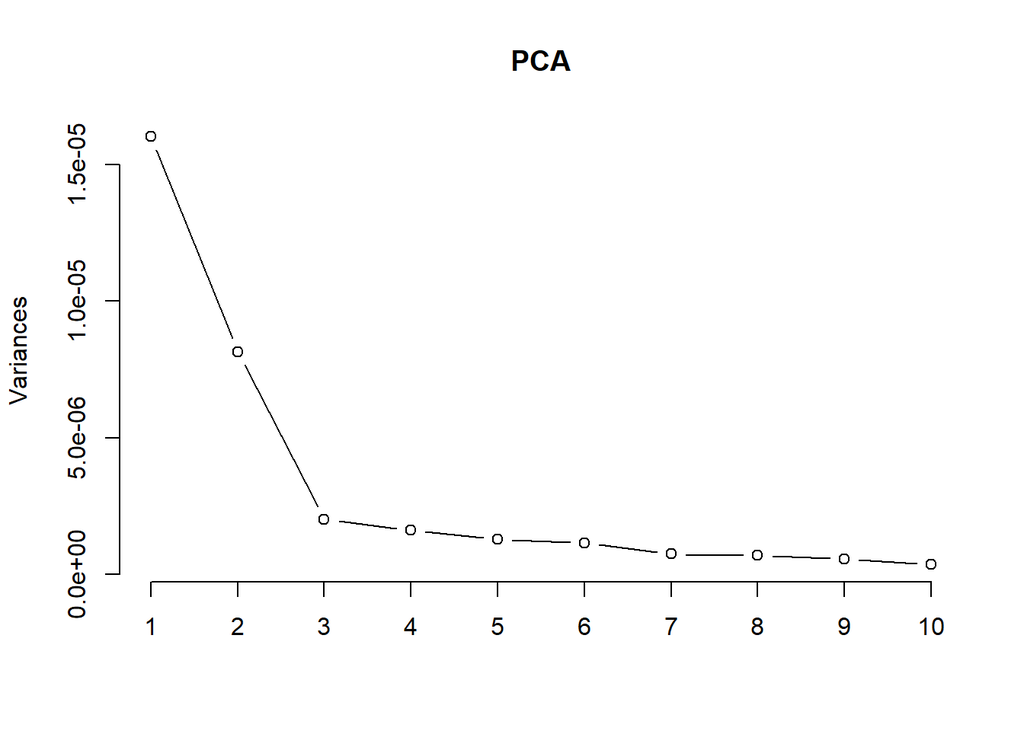

```r
# Plot the skree plot
i4 <- plot(PCA, type = "l")
```

```r
print(i4)
```

The elbow is seen in the PCA scree plot as intended. It would terminate at two, implying that the first and second eigenvalues and eigenvectors account for the bulk of variance.

We can see this below that the majority of the proportion of variance is explained by the first and second PCA, under `PC1` and `PC2`. PCA is simply a dimension reduction of sorts, we want to see in lower dimensions, how can we explain majority of the variation, hence the norm is to cut off at the elbow where the proportion of variation explained starts to deminish.

```r
i2 <- summary(PCA)
print(i2)
```

```
## Importance of components:
##                             PC1      PC2      PC3      PC4      PC5      PC6
## Standard deviation     0.004001 0.002852 0.001423 0.001276 0.001135 0.001079
## Proportion of Variance 0.467120 0.237460 0.059110 0.047560 0.037620 0.033960
## Cumulative Proportion  0.467120 0.704580 0.763700 0.811250 0.848870 0.882840
##                              PC7       PC8       PC9      PC10      PC11
## Standard deviation     0.0008722 0.0008349 0.0007587 0.0006079 0.0004087
## Proportion of Variance 0.0222000 0.0203400 0.0168000 0.0107900 0.0048700
## Cumulative Proportion  0.9050400 0.9253800 0.9421800 0.9529600 0.9578400
##                             PC12      PC13      PC14      PC15     PC16
## Standard deviation     0.0003829 0.0003571 0.0003364 0.0003143 0.000282
## Proportion of Variance 0.0042800 0.0037200 0.0033000 0.0028800 0.002320
## Cumulative Proportion  0.9621100 0.9658400 0.9691400 0.9720200 0.974340
##                             PC17      PC18      PC19     PC20      PC21
## Standard deviation     0.0002768 0.0002703 0.0002572 0.000231 0.0002264
## Proportion of Variance 0.0022400 0.0021300 0.0019300 0.001560 0.0015000
## Cumulative Proportion  0.9765800 0.9787100 0.9806400 0.982200 0.9836900
##                             PC22      PC23      PC24      PC25      PC26
## Standard deviation     0.0002146 0.0002088 0.0001835 0.0001755 0.0001707
## Proportion of Variance 0.0013400 0.0012700 0.0009800 0.0009000 0.0008500
## Cumulative Proportion  0.9850400 0.9863100 0.9872900 0.9881900 0.9890400
##                             PC27      PC28      PC29      PC30      PC31
## Standard deviation     0.0001667 0.0001534 0.0001494 0.0001406 0.0001396
## Proportion of Variance 0.0008100 0.0006900 0.0006500 0.0005800 0.0005700
## Cumulative Proportion  0.9898500 0.9905400 0.9911900 0.9917700 0.9923400
##                             PC32      PC33      PC34     PC35     PC36
## Standard deviation     0.0001355 0.0001313 0.0001274 0.000125 0.000119
## Proportion of Variance 0.0005400 0.0005000 0.0004700 0.000460 0.000410
## Cumulative Proportion  0.9928700 0.9933800 0.9938500 0.994310 0.994720
##                             PC37      PC38      PC39      PC40      PC41
## Standard deviation     0.0001164 0.0001123 0.0001066 0.0001058 0.0001013
## Proportion of Variance 0.0004000 0.0003700 0.0003300 0.0003300 0.0003000
## Cumulative Proportion  0.9951200 0.9954800 0.9958200 0.9961400 0.9964400
##                             PC42      PC43      PC44      PC45      PC46
## Standard deviation     9.439e-05 9.071e-05 8.701e-05 8.538e-05 8.122e-05
## Proportion of Variance 2.600e-04 2.400e-04 2.200e-04 2.100e-04 1.900e-04
## Cumulative Proportion  9.967e-01 9.969e-01 9.972e-01 9.974e-01 9.976e-01
##                             PC47      PC48      PC49      PC50      PC51
## Standard deviation     7.946e-05 7.675e-05 7.607e-05 7.534e-05 7.418e-05
## Proportion of Variance 1.800e-04 1.700e-04 1.700e-04 1.700e-04 1.600e-04
```

[output cut: 14 more lines]

```
## Standard deviation     0.0000383 3.321e-05 0.0000328 3.133e-05 2.967e-05
## Proportion of Variance 0.0000400 3.000e-05 0.0000300 3.000e-05 3.000e-05
## Cumulative Proportion  0.9997700 9.998e-01 0.9998300 9.999e-01 9.999e-01
##                             PC72      PC73      PC74      PC75      PC76
## Standard deviation     2.761e-05 2.621e-05 2.522e-05 2.469e-05 1.898e-05
## Proportion of Variance 2.000e-05 2.000e-05 2.000e-05 2.000e-05 1.000e-05
## Cumulative Proportion  9.999e-01 9.999e-01 9.999e-01 1.000e+00 1.000e+00
##                             PC77      PC78      PC79      PC80      PC81
## Standard deviation     1.724e-05 1.681e-05 1.436e-05 1.146e-05 3.254e-06
## Proportion of Variance 1.000e-05 1.000e-05 1.000e-05 0.000e+00 0.000e+00
## Cumulative Proportion  1.000e+00 1.000e+00 1.000e+00 1.000e+00 1.000e+00
##                            PC82
## Standard deviation     1.04e-06
## Proportion of Variance 0.00e+00
## Cumulative Proportion  1.00e+00
```

```r
    print(i2$importance)
```

```
##                                PC1         PC2        PC3         PC4
## Standard deviation     0.004000685 0.002852458 0.00142316 0.001276492
## Proportion of Variance 0.467120000 0.237460000 0.05911000 0.047560000
## Cumulative Proportion  0.467120000 0.704580000 0.76370000 0.811250000
##                                PC5         PC6          PC7          PC8
## Standard deviation     0.001135415 0.001078716 0.0008721694 0.0008348617
## Proportion of Variance 0.037620000 0.033960000 0.0222000000 0.0203400000
## Cumulative Proportion  0.848870000 0.882840000 0.9050400000 0.9253800000
##                                 PC9         PC10         PC11        PC12
## Standard deviation     0.0007586619 0.0006079235 0.0004086636 0.000382895
## Proportion of Variance 0.0168000000 0.0107900000 0.0048700000 0.004280000
## Cumulative Proportion  0.9421800000 0.9529600000 0.9578400000 0.962110000
##                                PC13        PC14         PC15         PC16
## Standard deviation     0.0003571069 0.000336355 0.0003142629 0.0002820095
## Proportion of Variance 0.0037200000 0.003300000 0.0028800000 0.0023200000
## Cumulative Proportion  0.9658400000 0.969140000 0.9720200000 0.9743400000
##                                PC17         PC18        PC19         PC20
## Standard deviation     0.0002767949 0.0002703163 0.000257181 0.0002309776
## Proportion of Variance 0.0022400000 0.0021300000 0.001930000 0.0015600000
## Cumulative Proportion  0.9765800000 0.9787100000 0.980640000 0.9822000000
##                                PC21         PC22         PC23         PC24
## Standard deviation     0.0002264293 0.0002146255 0.0002088306 0.0001834849
## Proportion of Variance 0.0015000000 0.0013400000 0.0012700000 0.0009800000
## Cumulative Proportion  0.9836900000 0.9850400000 0.9863100000 0.9872900000
##                                PC25         PC26         PC27         PC28
## Standard deviation     0.0001754799 0.0001707251 0.0001666813 0.0001534124
## Proportion of Variance 0.0009000000 0.0008500000 0.0008100000 0.0006900000
## Cumulative Proportion  0.9881900000 0.9890400000 0.9898500000 0.9905400000
##                                PC29         PC30         PC31         PC32
## Standard deviation     0.0001494399 0.0001406482 0.0001396005 0.0001354963
## Proportion of Variance 0.0006500000 0.0005800000 0.0005700000 0.0005400000
## Cumulative Proportion  0.9911900000 0.9917700000 0.9923400000 0.9928700000
##                                PC33         PC34         PC35         PC36
## Standard deviation     0.0001313256 0.0001273902 0.0001250035 0.0001190166
## Proportion of Variance 0.0005000000 0.0004700000 0.0004600000 0.0004100000
## Cumulative Proportion  0.9933800000 0.9938500000 0.9943100000 0.9947200000
##                                PC37         PC38         PC39        PC40
## Standard deviation     0.0001164377 0.0001122846 0.0001066153 0.000105794
## Proportion of Variance 0.0004000000 0.0003700000 0.0003300000 0.000330000
## Cumulative Proportion  0.9951200000 0.9954800000 0.9958200000 0.996140000
```

[output cut: 29 more lines]

```
## Standard deviation     3.279546e-05 3.133077e-05 2.966771e-05 2.76068e-05
## Proportion of Variance 3.000000e-05 3.000000e-05 3.000000e-05 2.00000e-05
## Cumulative Proportion  9.998300e-01 9.998600e-01 9.998800e-01 9.99910e-01
##                                PC73         PC74         PC75         PC76
## Standard deviation     2.621049e-05 2.522452e-05 2.469333e-05 1.897514e-05
## Proportion of Variance 2.000000e-05 2.000000e-05 2.000000e-05 1.000000e-05
## Cumulative Proportion  9.999300e-01 9.999400e-01 9.999600e-01 9.999700e-01
##                                PC77         PC78         PC79         PC80
## Standard deviation     1.724294e-05 1.680641e-05 1.435798e-05 1.145594e-05
## Proportion of Variance 1.000000e-05 1.000000e-05 1.000000e-05 0.000000e+00
## Cumulative Proportion  9.999800e-01 9.999900e-01 1.000000e+00 1.000000e+00
##                                PC81         PC82
## Standard deviation     3.254463e-06 1.039743e-06
## Proportion of Variance 0.000000e+00 0.000000e+00
## Cumulative Proportion  1.000000e+00 1.000000e+00
```

```r
    print(0.467120000 + 0.237460000)
```

```
## [1] 0.70458
```

The first 2 components explain 0.70458 of the variation.

#Question 4

```r
# ============== Preamble to load packages ========================== #
if(!require("devtools")){install_github("devtools")}
library(devtools)

# Install pacman to handle installations
if(!require("trinker/pacman")){install_github("trinker/pacman")}
```

```
## Skipping install of 'pacman' from a github remote, the SHA1 (ace09364) has not changed since last install.
##   Use `force = TRUE` to force installation
```

```r
# Install the required packages in elagant approach
pacman::p_load(
    "tidyverse",
    "devtools",
    "rugarch",
    "forecast",
    "tbl2xts",
    "lubridate",
    "PerformanceAnalytics",
    "ggthemes",
    "robustbase",
    "tbl2xts",
    "PerformanceAnalytics",
    "ggplot2",
    "tidyverse",
    "fmxdat",
    "extrafont",
    "TTR",
    "naniar",
    "readr",
    "dplyr",
    "tidyr",
    "MTS",
    "robustbase",
    "rportfolios",
    "zoo",
    "dLagM"
)
```

```r
#Import the data
cncy <- read_rds("data/currencies.rds")
cncy_Carry <- read_rds("data/cncy_Carry.rds")
cncy_value <- read_rds("data/cncy_value.rds")
cncyIV <- read_rds("data/cncyIV.rds")
bbdxy <- read_rds("data/bbdxy.rds")
```

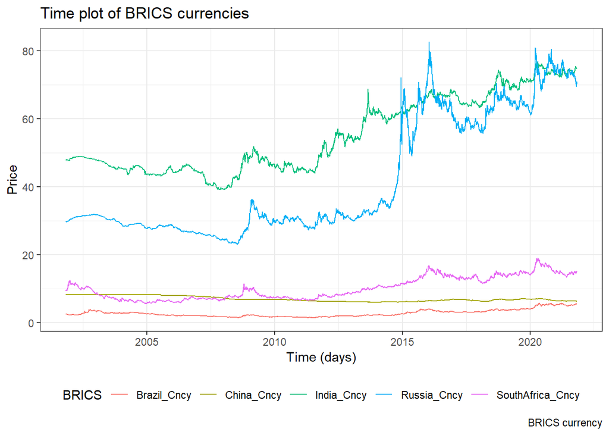

```r
cncy %>%
    # take last 20 years
    filter(date >= "2001-10-31" & date <= "2021-10-31") %>%
    # format for BRICS countries
    filter(
        Name %in% c(
            "Brazil_Cncy",
            "Russia_Cncy",
            "SouthAfrica_Cncy",
            "China_Cncy",
            "India_Cncy"
        )
    ) %>%
    # plot
    ggplot() +
    aes(x = date, y = Price, colour = Name) +
    geom_line(size = 0.5) +
    scale_color_hue(direction = 1) +
    labs(
        x = "Time (days)",
        y = "Price",
        title = "Time plot of BRICS currencies",
        caption = "BRICS currency",
        color = "BRICS"
    ) +
    theme_bw() +
    theme(legend.position = "bottom")
```

```r
cncy %>%
    # filter last 20 years
    filter(date >= "2001-10-31" & date <= "2021-10-31") %>%
    # BRICS
    filter(
        Name %in% c(
            "Brazil_Cncy",
            "Russia_Cncy",
            "SouthAfrica_Cncy",
            "China_Cncy",
            "India_Cncy"
        )
    ) %>% group_by(Name) %>% summary()
```

```
##       date                Name               Price
##  Min.   :2001-10-31   Length:26090       Min.   : 1.539
##  1st Qu.:2006-10-31   Class :character   1st Qu.: 6.353
##  Median :2011-10-31   Mode  :character   Median : 9.308
##  Mean   :2011-10-30                      Mean   :23.514
##  3rd Qu.:2016-10-31                      3rd Qu.:43.749
##  Max.   :2021-10-29                      Max.   :82.684
```

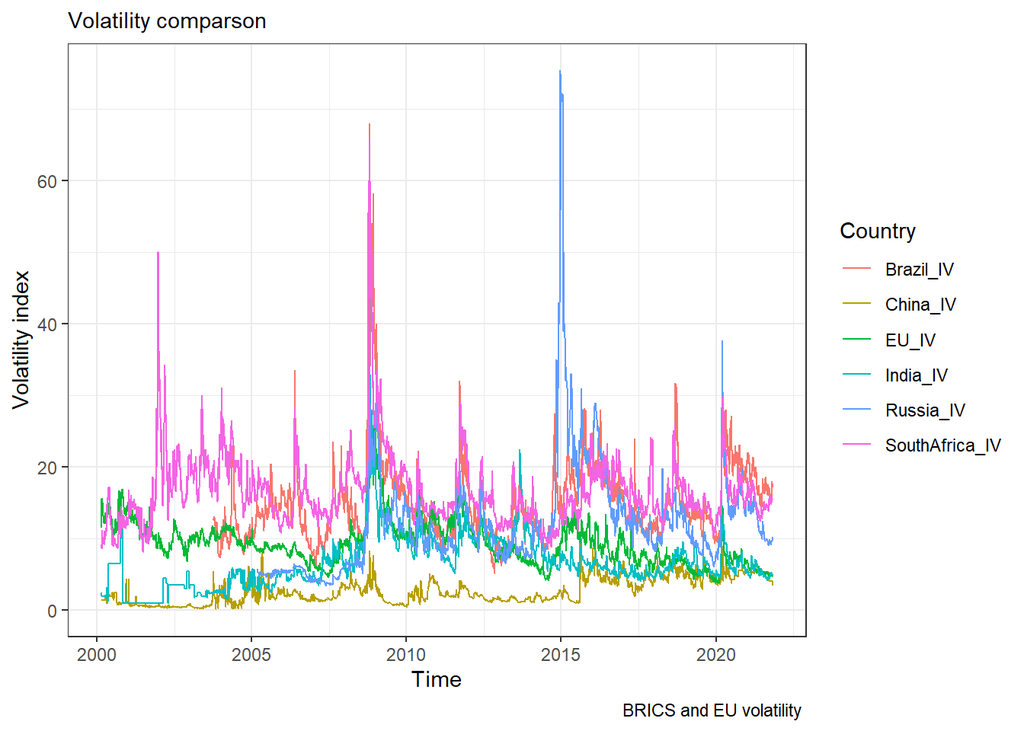

```r
cncyIV %>%
    filter(date >= "2000-02-19" & date <= "2021-10-29") %>%
    filter(
        Name %in% c(
            "Brazil_IV",
            "China_IV",
            "EU_IV",
            "India_IV",
            "SouthAfrica_IV",
            "Russia_IV"
        )
    ) %>%
    ggplot() +
    aes(x = date, y = Price, colour = Name) +
    geom_line(size = 0.5) +
    scale_color_hue(direction = 1) +
    labs(
        x = "Time",
        y = "Volatility index",
        subtitle = "Volatility comparson",
        caption = "BRICS and EU volatility ",
        color = "Country"
    ) +
    theme_bw()
```

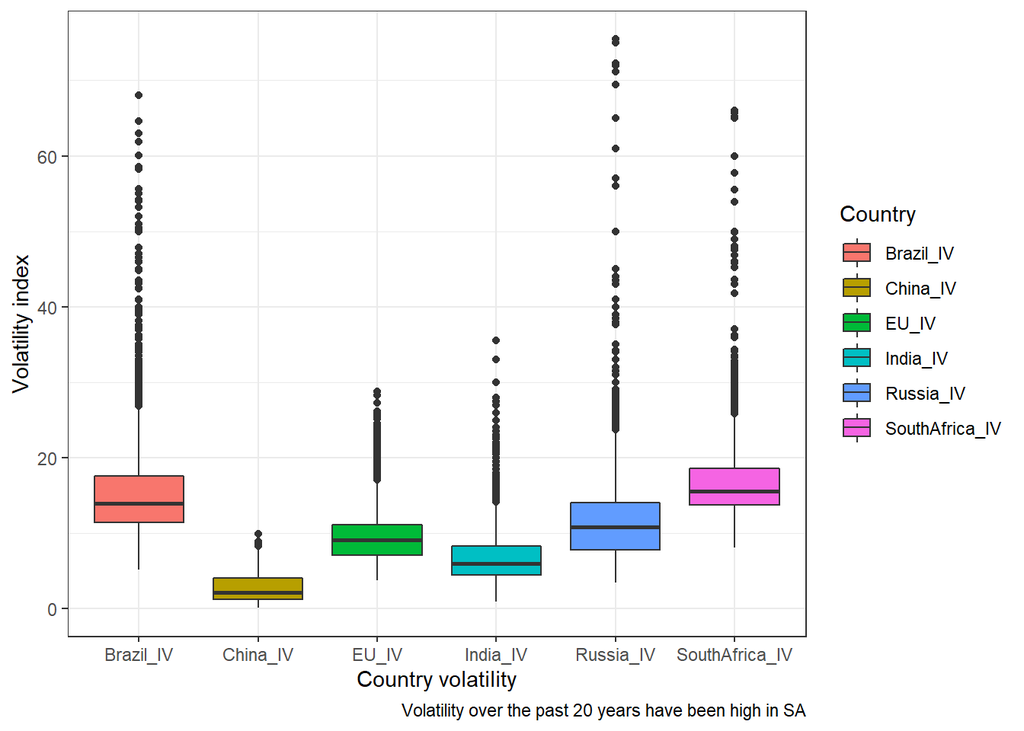

```r
temp <- cncyIV %>%
 filter(date >= "2000-02-19" & date <= "2021-10-29") %>%
 filter(Name %in% c("Brazil_IV", "China_IV",
"EU_IV", "India_IV", "SouthAfrica_IV", "Russia_IV"))

ggplot(temp) +
  aes(x = Name, y = Price, fill = Name) +
  geom_boxplot(shape = "circle") +
  scale_fill_hue(direction = 1) +
  labs(
    x = "Country volatility",
    y = "Volatility index",
    caption = "Volatility over the past 20 years have been high in SA",
    fill = "Country"
  ) +
  theme_bw()
```

```r
# G10
glimpse(cncy_Carry)
```

```
## Rows: 5,445
## Columns: 3
## $ date  <date> 2000-09-18, 2000-09-19, 2000-09-20, 2000-09-21, 2000-09-22, 200~
## $ Name  <chr> "DBHVG10U", "DBHVG10U", "DBHVG10U", "DBHVG10U", "DBHVG10U", "DBH~
## $ Price <dbl> 100.00, 99.53, 99.38, 99.31, 99.22, 99.86, 99.89, 100.11, 99.60,~
```

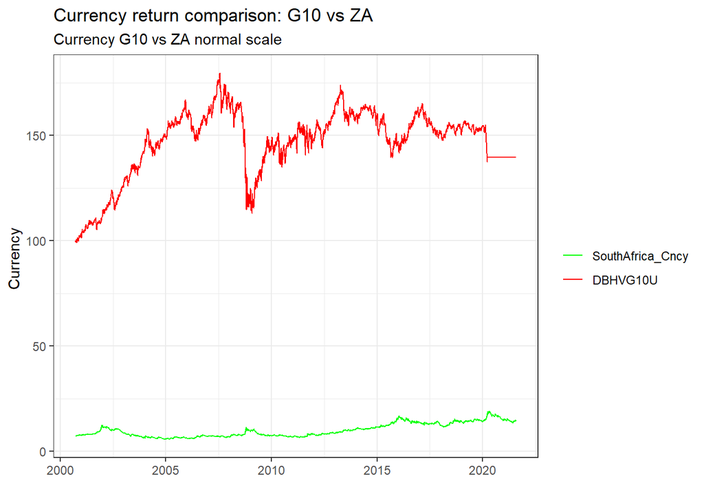

```r
# subset south african currency
ZAR <-
    cncy %>%
    filter(Name == "SouthAfrica_Cncy") %>%
    select(date, Price)

# rename columns in order to plot
colnames(ZAR)[2] <- "SouthAfrica_Cncy"
colnames(cncy_Carry)[3] <- "DBHVG10U"

# inner join by date
temp <- inner_join(cncy_Carry, ZAR, by = "date")


# Plot a currency comparison of the G10 and ZA
p1 <-
    ggplot(data = temp, aes(x = date)) +
    geom_line(aes(y = DBHVG10U, colour = "DBHVG10U")) +
    geom_line(aes(y = SouthAfrica_Cncy, colour = "SouthAfrica_Cncy")) +
    scale_colour_manual(
        "",
        breaks = c("SouthAfrica_Cncy", "DBHVG10U"),
        values = c("SouthAfrica_Cncy" = "green", "DBHVG10U" =
                       "red")
    ) +
    xlab(" ") +
    scale_y_continuous("Currency ") +
    labs(title = "Currency return comparison: G10 vs ZA",
         subtitle = "Currency G10 vs ZA normal scale") +
  theme_bw()

p1
```

It is difficult to compare the SA and the G10 in `DBHVG10U` and South African currencies as they are on different scales. We can try to scale both measures to ensure that a fair comparison of their synchrony takes place.

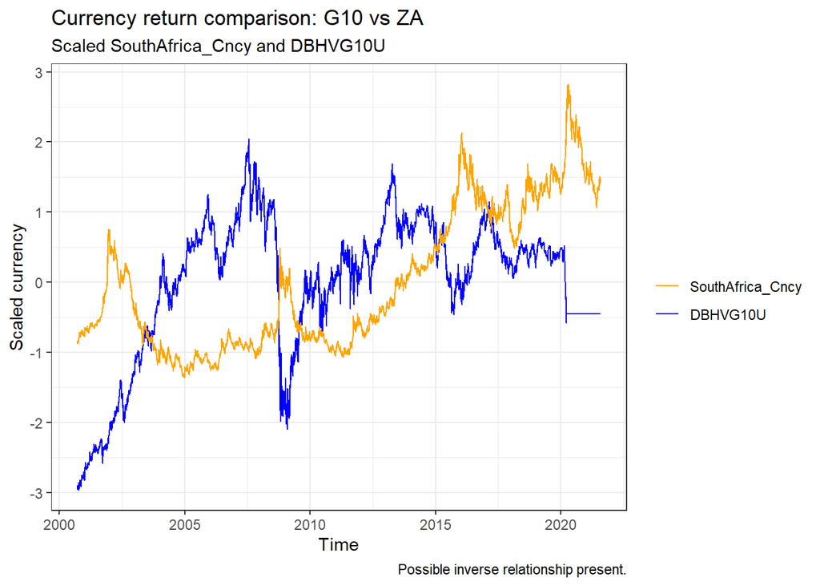

```r
#
temp <- temp %>%
    select(-Name)

p2 <-
ggplot(data = temp, aes(x = date)) +
  geom_line(aes(y = scale(DBHVG10U), colour = "DBHVG10U")) +
  geom_line(aes(y = scale(SouthAfrica_Cncy), colour = "SouthAfrica_Cncy")) +
  scale_colour_manual("",
                      breaks = c("SouthAfrica_Cncy", "DBHVG10U"),
                      values = c("SouthAfrica_Cncy"="orange", "DBHVG10U"="blue")) +
  xlab("Time") +
  scale_y_continuous("Scaled currency") +
  labs(title="Currency return comparison: G10 vs ZA",
       subtitle = "Scaled SouthAfrica_Cncy and DBHVG10U",
       caption = "Possible inverse relationship present.") +
  theme_bw()

p2
```

We observe from the scaled currencies a possible inverse relationship. In order to truly understand the synchrony of the currencies, we could use the correlation. This is the standard approach to consider the synchrony of two variables, but since this is also a time series problem, the time dimension is a factor in determining the correct approach. A rolling window has the added benefit of allowing you to include the time dimension but without eliminating the bias-variance trade-off in the window size. For more on this see work by Tsay in his 2013 book on multivariate time series.

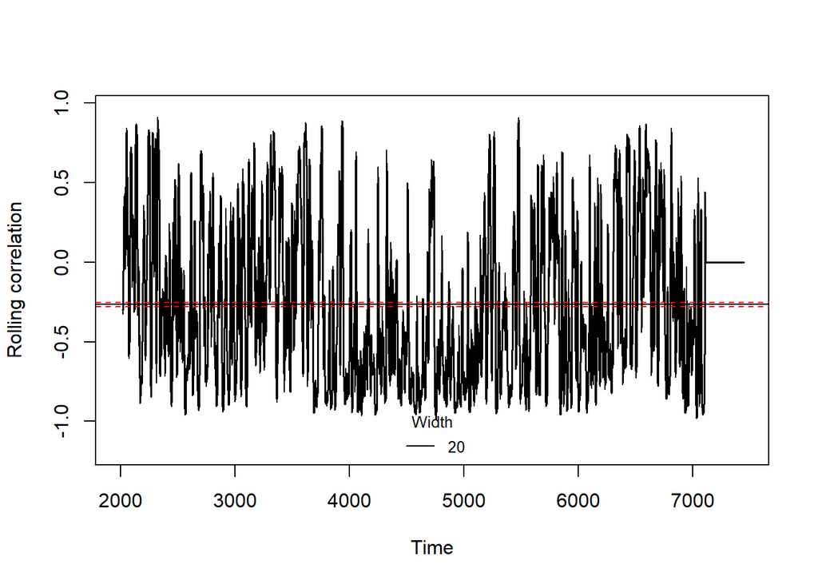

[output not shown]

[output cut: 7628 more lines]

```r
if(!require("dLagM")){install_github("dLagM")}

temp <- temp %>% select(date, DBHVG10U, SouthAfrica_Cncy)

prod.ts <- ts(temp$DBHVG10U, start = 2000)
CO2.ts <- ts(temp$SouthAfrica_Cncy, start = 2000)
rolCorPlot(
    x = prod.ts,
    y = CO2.ts ,
    width = c(20),
    level = 0.95
)
```

An analysis of the rolling correlation with a window showing the confidence interval, considering a 20 day window show that the correlation is generally slightly negative. Further supporting the argument that there is an inverse relationship, i.e. if ZA goes up, G10 goes down in general.

#Question 5